# Possibility generation

Jiani Ge

February 2022

### Procedure

We collected a sample of 104 participants from Amazon Mechanical Turk (www.mturk.com).

After excluding non-answers, the dataset consists of 3242 generated actions and 12972 ratings.

### Results

1. Before we explore any relationship between the variables, histograms of the participants’ ratings of the actions they generated show that, overall, most of the actions they generated are highly moral, normal, probable, and rational. This could suggest that in open-ended possibility generation, people tend to come up with possible actions that are moral, normal, probable, and rational.

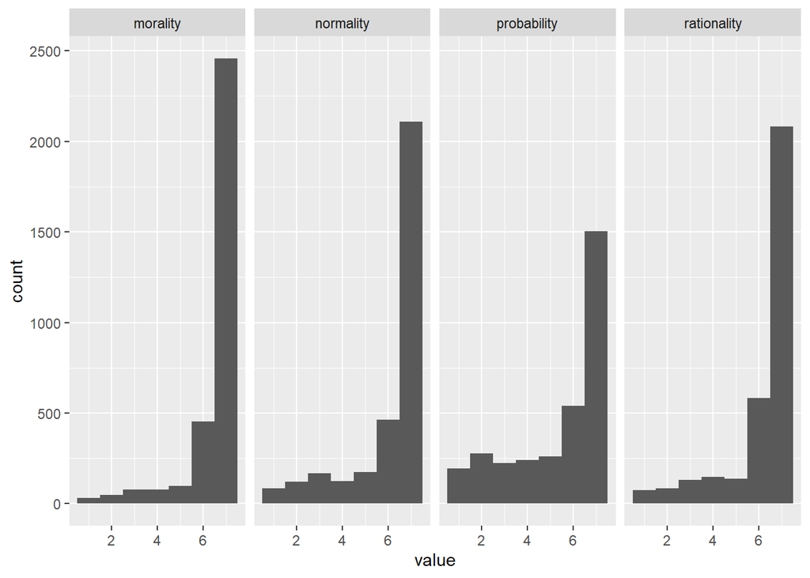

2. While the generated possible actions are overall highly moral, probable, rational, and normal, there are several factors that could affect the ratings. We first looked at the relationship between a possible action’s ratings and its position in the series of actions that the participants generate for the scenario (answer order). As the barplot below shows, ratings for each criterion decrease from earlier answers to later ones.

Overall, earlier answers tend to be rated as more moral, probable, rational, and normal. This is consistent with the hypothesis that these “values” constrain people’s representation of possible actions and that the less people deliberate, the stronger the effect of the constraints.

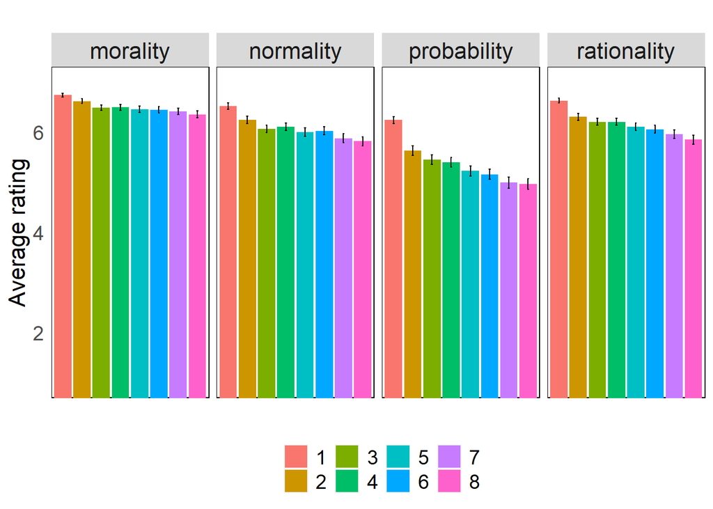

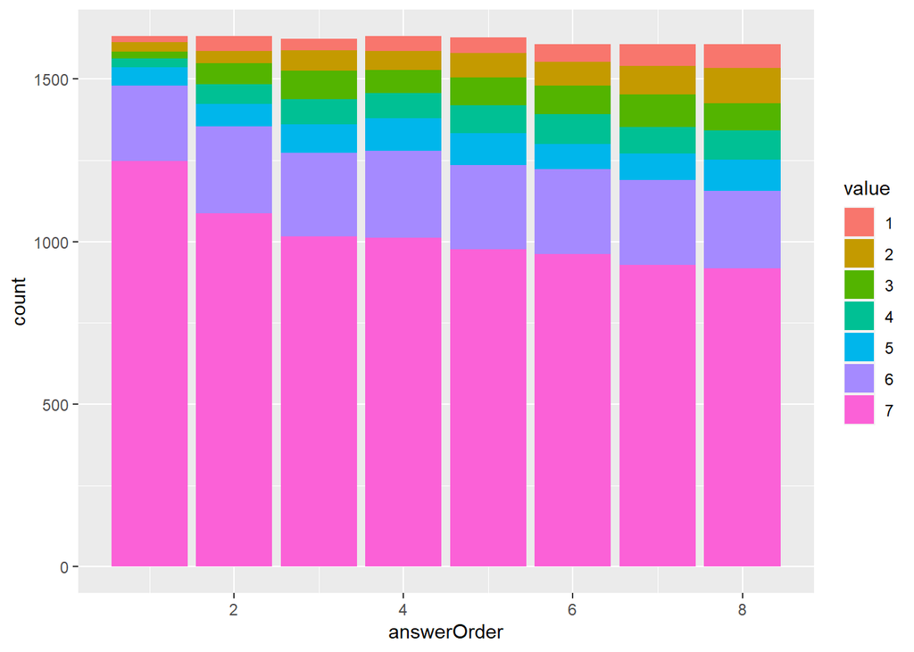

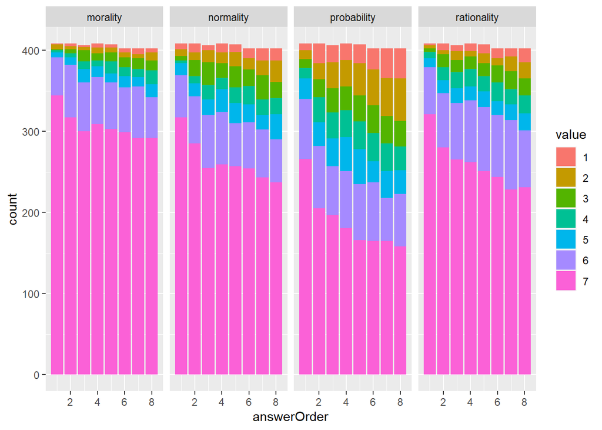

3. To confirm that answer order indicates deliberation, we looked at the relationship between answer order and the time spent on generating the answer. A comparison between linear mixed-effects models shows that there is a significant main effect of answer order (chisq(7)=127.23, p<2.2e-16). Earlier answers are generated faster than later ones.

There is also a significant main effect of rating on time to answer (chisq(1)=8.5486, p=0.003458). More highly rated answers are generated faster - consistent with the previous analysis.

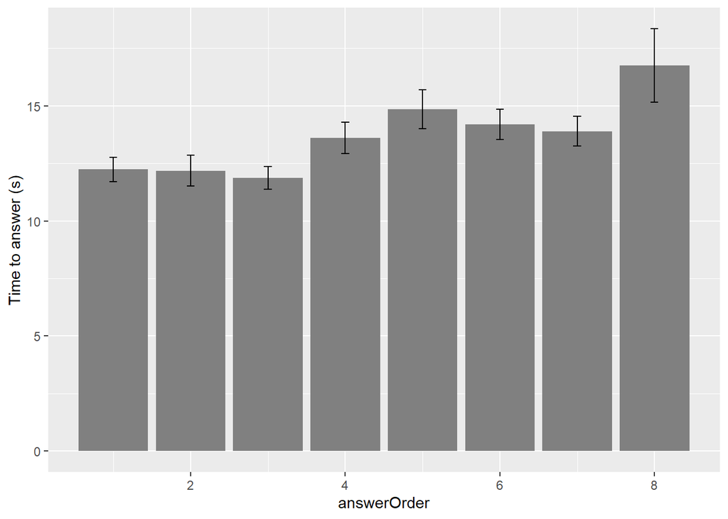

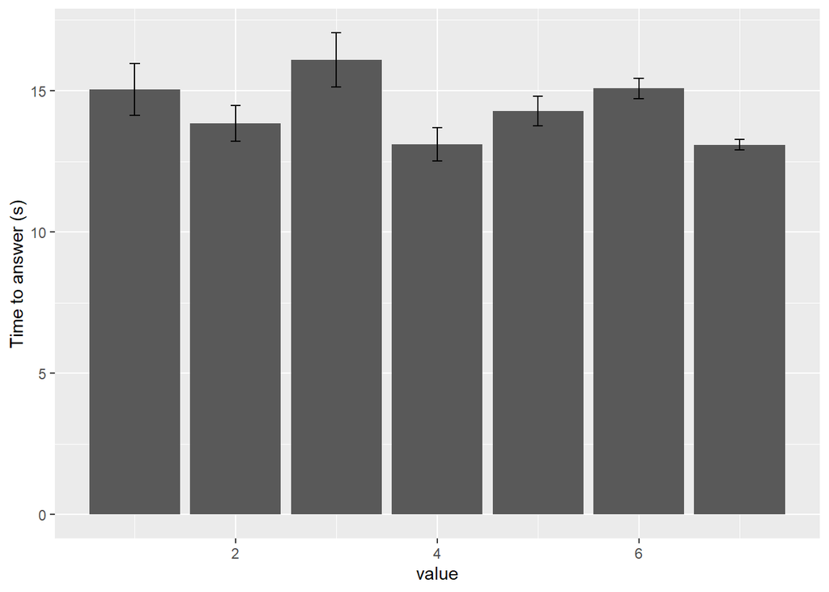

4. We hypthesize that in addition to the above-examined values (morality, rationality, probability, normality), the extent to which the generated action is specific to the scenario also differs across the generation/deliberation process. We coded the generated actions into binary categories based on whether they are explicitly related to the scenario or not. The barplots below suggest that, overall, earlier answers are more likely to be explicitly related to the scenario. A comparison between generalized linear mixed model confirmed that the effect is significant (chisq(7)=378.71, p<2.2e-16).

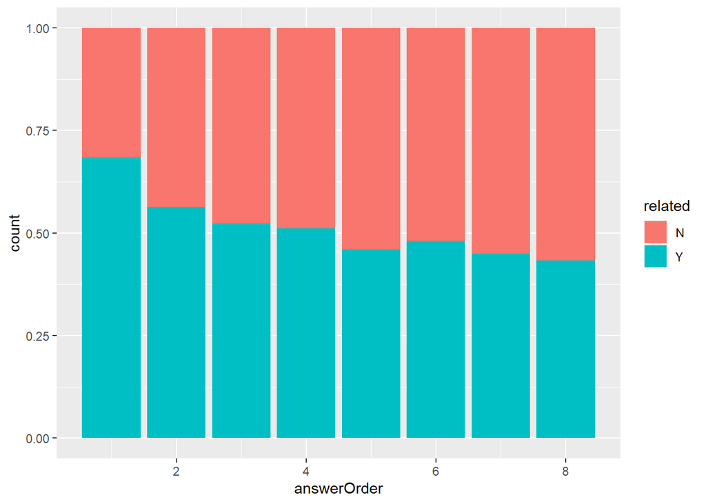

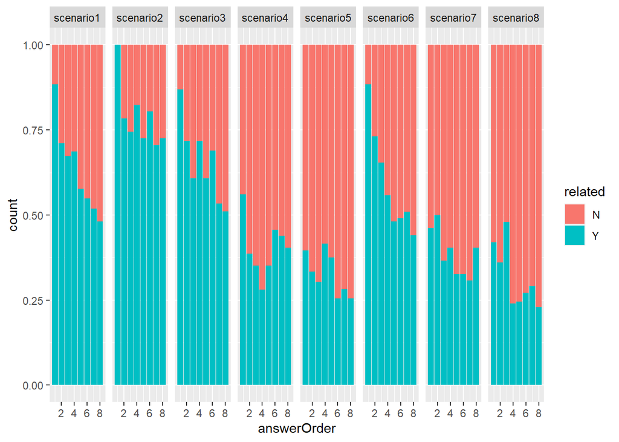

5. We also coded the generated actions into binary categories based on whether they violate the conventions related to the scenarios. The barplots below show that there is overall an increase of unconventional actions (or decrease of conventionality) from ealier to later answers. A comparion between generalized linear mixed models show that the effect is significant (chisq(1)=5.532, p=0.01867).

There is significant variation between the scenarios. Interestingly, people generated much more unconventional actions for scenario 7 than others. My speculation is that scenario 7 is the only scenario in which the participant would be aloone in the situation, unobserved by other people. Whether people are being observed could be a factor affecting how likely they conform to the convention.

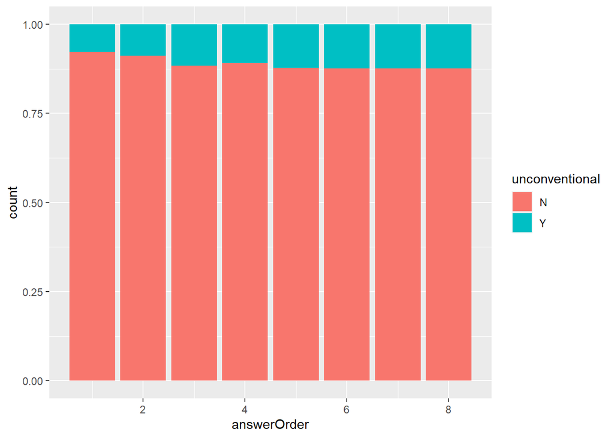

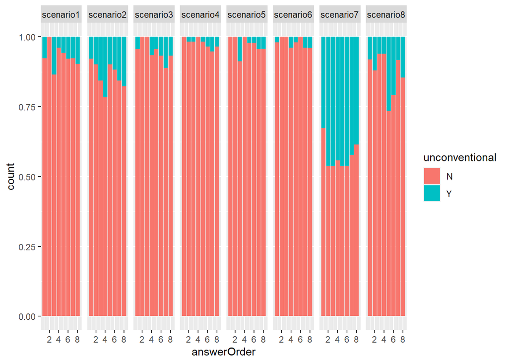

6. Here’s an attempt to visualize conventionality and the participants’ own morality and probability ratings in the same graph.

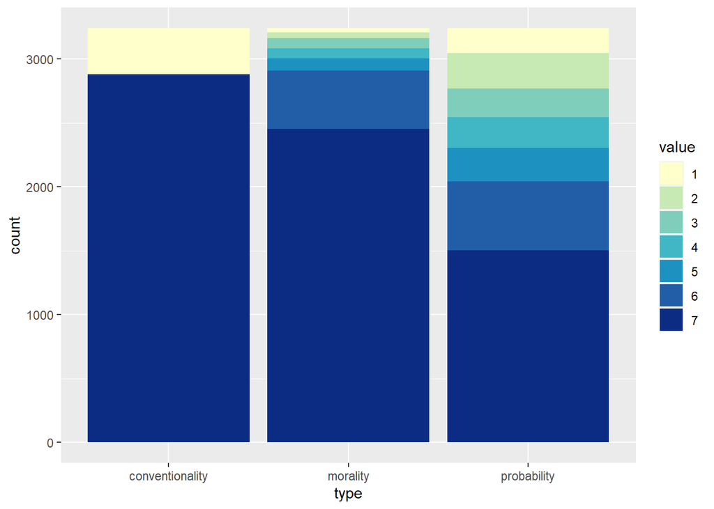